# Stochastic Basic Virus Model

## Overview

This app allows exploration of a stochastic model that is almost identical to the deterministic basic virus infection model. In fact, both models are being run so comparison is possible. Read about the model in the “Model” tab. Then do the tasks described in the “What to do” tab.

## The Model

### Model Description

This model consists of 3 compartments and is almost identical to the deterministic basic virus infection model. We track the following entities, by assigning each to a compartment:

- **U** - uninfected cells
- **I** - infected cells
- **V** - (free) virus

In addition to specifying the *compartments* of a model, we need to specify the dynamics determining the changes for each compartment. Broadly speaking, there are processes that increase the numbers in a given compartment/stage, and processes that lead to a reduction.

For this model, we consider the following processes:

1. Uninfected cells are produced at some rate *n* and naturally die at some rate *dU*.
2. Virus infects cells at rate *b*.
3. Infected cells produce new virus at rate *p* and die at rate *dI*.
4. Free virus is removed at rate *dV* or goes on to infect further uninfected cells.

The one difference to the deterministic virus model is that we do not include an additional conversion factor to account for experimental units. The reason is that this stochastic model makes the assumption that all entities/variables are in discrete units, i.e. number of cells and number of (infectious) virions, and can only change by integer numbers. Because of that, our model requires that virus is in units of actual virion numbers and we don’t need to convert. That also means that the parameter *g* of the deterministic model - which we run for comparison - is set to 1.

### Model Diagram

The diagram illustrating this compartmental model is shown in the figure.

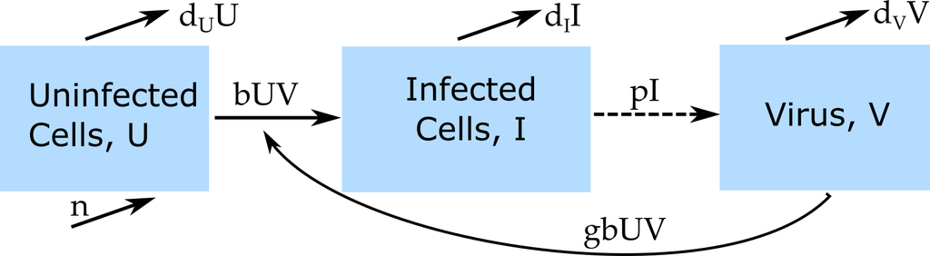

Flow diagram for a simple virus infection model.

### Model Equations

*If* we were to implement this model as a continuous-time, deterministic model, it would have the following set of ordinary differential equations.

$$\dot U = n - dU - bUV$$
$$\dot I = bUV - d_I I$$
$$\dot V = pI - d_V V - b UV$$

*However* we use a stochastic model here. For such a model, the differential equation formulation is not valid. One can write down an equivalent formulation as a stochastic model by specifying every possible process (also called transition/event/reaction) that can occur and their propensities (the propensity multiplied with the time step gives the probability that a given process/event/transition occurs). For our model these are the following:

[output not shown]

## What to do

### Task 1:

- When you start the app, by default the deterministic model is run and you should see an infection happening. Switch to the stochastic model with the same parameter settings and run the model. You should not see an outbreak.
- Change the random number seed and find a value for which you do get an outbreak.
- Set “Models to run” to both. You should get infections from each model. Compare how they differ.
- Increase the number of simulations (for the stochastic model) to 10, then 20. Look at the results, try to understand what you see.
- Try the previous 2 steps for several different random number seeds.

### Task 2:

- Turn off the deterministic model.
- Run the stochastic model with 5 simulations for different random seeds. See how the maximum number of infected cells changes.
- Now repeat for 50 stochastic simulations. You should see less variation now since you average over more simulations. The more simulations, the more robust the results are (but it takes longer to run). Ideally, you’d like to always be in a setting where arbitrary choices, such as the initial random number seed, do not (or only negligibly) influence your results.

### Task 3:

- Turn the deterministic model back on, run 50 stochastic simulations. Notice that the deterministic model is not ‘the average’ of the stochastic simulations. It is true that for *linear* models, the mean of many stochastic models is described by the deterministic model. But that is not true for *nonlinear* models like the one we have here. It’s an important point to keep in mind if you build models and try both a deterministic and stochastic one. You don’t necessarily get the same results, even if you average over many stochastic model runs.

### Task 4:

- Turn off the deterministic model, keep all parameter values as before (if you changed them, exit the app and reload). Set number of simulations to 2, random number seed to 100.
- Run simulation. You should see 2 stochastic model runs, one where you get an infection and one where you don’t.
- Look at the min/max/final values reported. Then do 4 stochastic runs, look at min/max/final values again.
- From that, what do you conclude about how the mean is calculated? What other way of reporting it might be a reasonable alternative?

### Task 5:

- Currently, stochasticity/randomness is a determining factor for the take-off or not of an infection. Once an infection has started, the resulting time-series look fairly smooth and not too noisy. Play around with the model parameters to try and find a regime where the whole infection dynamics looks stochastic/noisy.

### Task 6:

- In doing the last task, you likely figured out that for small numbers, you get more noisy results. Set the number of uninfected cells to 100 and the infection rate to 10<sup>-2</sup>. Run several stochastic outbreaks. You should see fairly random virus and infected cell plots.

### Task 7:

- Keep exploring. For instance investigate chronic/steady state conditions (with uninfected cell birth/death turned on) and see how they might or might not differ between the deterministic and (average) stochastic simulations.

## Further Information

- This app (and all others) are structured such that the Shiny part (the graphical interface you see and the server-side function that goes with it) calls an underlying R script (or several) which runs the simulation for the model of interest and returns the results.
- For this app, the underlying function running the simulation is called `simulate_basicvirus_stochastic, simulate_basicvirus_ode`. You can call them directly, without going through the shiny app. Use the `help()` command for more information on how to use the functions directly. If you go that route, you need to use the results returned from this function and produce useful output (such as a plot) yourself.
- You can also download all simulator functions and modify them for your own purposes. Of course to modify these functions, you’ll need to do some coding.
- For examples on using the simulators directly and how to modify them, read the package vignette by typing `vignette('DSAIRM')` into the R console.